# Bayesian Hierarchical Modeling of U.S. Real-Estate Listing Prices

A fully Bayesian state-ZIP analysis with heteroskedastic residuals

Final FSLII Project

06 luglio 2026

# 1 Abstract

This report presents a fully Bayesian analysis of U.S. residential real-estate listing prices using hierarchical regression models fitted by MCMC. The data contain 2,226,382 raw listings from 55 states and territories and 30,334 ZIP codes. The modeling frame uses a balanced geographic sample with 14,400 training listings, 3,600 held-out listings, 25 states, and 600 state-ZIP groups.

Three Bayesian models are compared: a pooled regression (M0), a state random-intercept model (M1), and a heteroskedastic state-ZIP hierarchical model (M2). The selected M2 model has the best DIC (15,333.34), the lowest held-out RMSE (0.4241), the lowest held-out MAE (0.2825), and calibrated 95% predictive coverage (0.9536). Posterior predictive checks show that M2 reproduces geographic heterogeneity well, with mild over-dispersion in the overall standardized log-price distribution.

# 2 Introduction

## 2.1 Motivation and goals

Real-estate prices vary with property characteristics such as living area, lot size, bedrooms, bathrooms, and listing status. They also vary geographically: two similar homes can have different listing prices because they are located in different states or local ZIP-code markets. A fully Bayesian hierarchical model is appropriate because it estimates fixed property effects, geographic variation, predictive uncertainty, and partial pooling within one coherent probability model.

The inferential goals are:

1. estimate associations between listing price and measured property features;
2. quantify state-level and ZIP-level residual price variation;
3. compare increasingly structured Bayesian models using DIC and held-out prediction;
4. verify MCMC reliability and simulation-based parameter recovery;
5. evaluate whether the fitted model reproduces relevant observed data features;
6. generate posterior predictive price distributions for interpretable real-estate scenarios.

The geographic parameters are descriptive and predictive associations. The data are observational listings, so the model does not identify causal effects of location, status, or property characteristics.

# 3 Data description and preprocessing

## 3.1 Source data

The dataset is the USA Real Estate Dataset from Kaggle, version 25, downloaded on 21 June 2026 (Ahmed Shahriar Sakib 2026). The raw CSV is preserved locally as `data/raw/realtor-data.csv`, has MD5 checksum `09ce5bd36ef648a5769a996735c05951`, and is excluded from version control.

```
##
##
## Table: Raw dataset overview.
##
## |quantity                  |value     |
## |:-------------------------|:---------|
## |Raw rows                  |2,226,382 |
## |Raw columns               |12        |
## |Unique states/territories |55        |
## |Unique cities             |20,098    |
## |Unique ZIP codes          |30,334    |
```

The modeling variables are price, living area, lot size, bedrooms, bathrooms, listing status, state, and ZIP code. Positive price and house size are required because the response and living area enter on the log scale. Lot size uses a `log1p` transformation so that zero-acre listings remain valid while extreme large lots are compressed.

```
##
##
## Table: Data dictionary and missingness for raw fields.
##
## |Variable       |Type       | Missing count| Missing percent|
## |:--------------|:----------|-------------:|---------------:|
## |brokered_by    |numeric    |          4533|           0.204|
## |status         |character  |             0|           0.000|
## |price          |numeric    |          1541|           0.069|
## |bed            |integer    |        481317|          21.619|
## |bath           |integer    |        511771|          22.987|
## |acre_lot       |numeric    |        325589|          14.624|
## |street         |numeric    |         10866|           0.488|
## |city           |character  |          1407|           0.063|
## |state          |character  |             8|           0.000|
## |zip_code       |integer    |           299|           0.013|
## |house_size     |numeric    |        568484|          25.534|
## |prev_sold_date |IDate/Date |        734297|          32.982|
```

## 3.2 Cleaning, transformations, and analysis sample

The response is standardized log listing price. Continuous covariates are also standardized using training-set information. The analysis uses a frozen balanced geographic sample: 25 states, 600 state-ZIP groups, 30 listings per state-ZIP group before splitting, and a 24/6 train/test split within each group.

```
##
##
## Table: Row accounting from raw data to the frozen analysis frame.
##
## |stage                      |       n|
## |:--------------------------|-------:|
## |Raw rows                   | 2226382|
## |Core valid rows            | 1605398|
## |Lot-size complete rows     | 1360626|
## |Frozen balanced sample     |   18000|
## |Frozen training sample     |   14400|
## |Frozen held-out sample     |    3600|
## |Selected states            |      25|
## |Selected state--ZIP groups |     600|
```

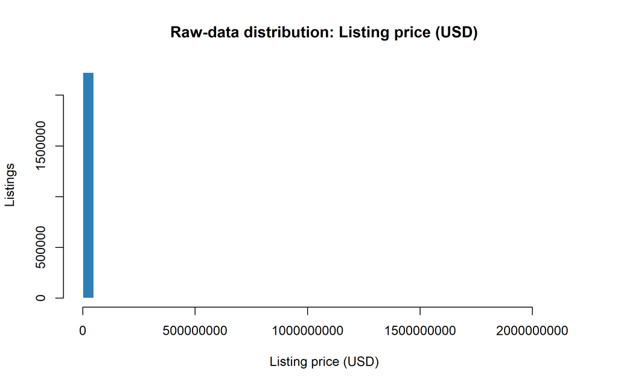

Raw listing prices are strongly right-skewed, motivating log-price modeling.

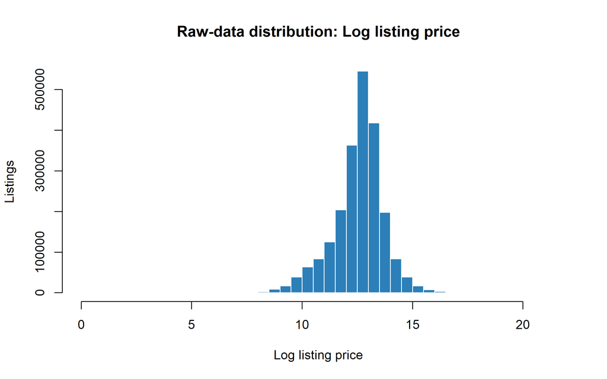

The log-price scale is closer to a regular unimodal distribution and is more compatible with Gaussian residual modeling.

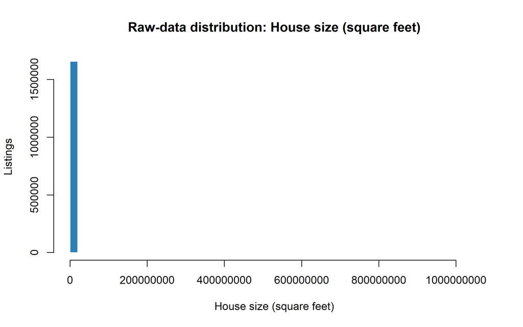

Raw house size is also right-skewed, with some high-leverage large homes.

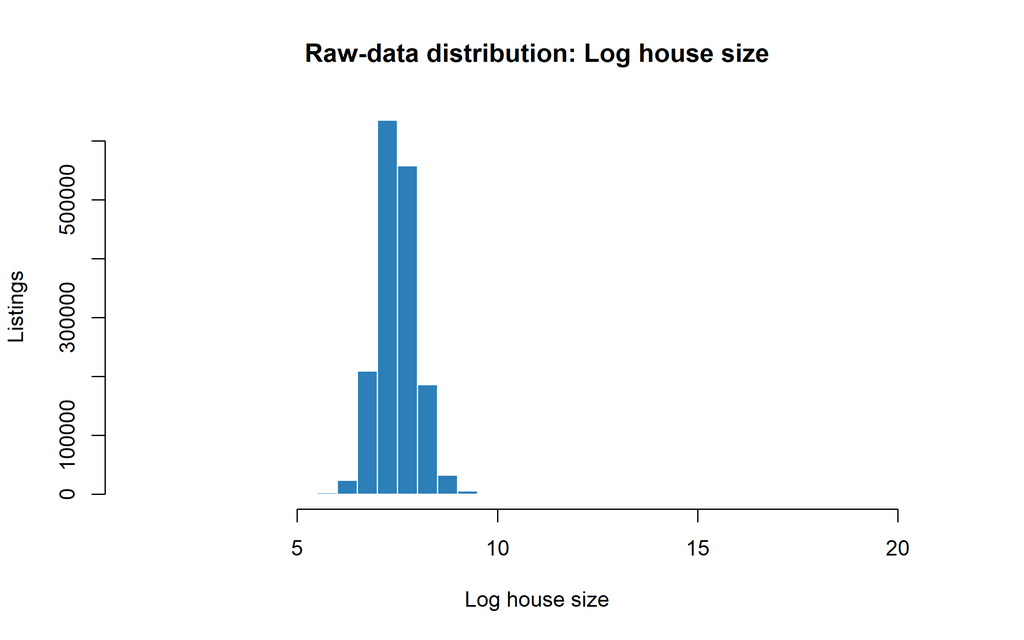

Log house size reduces skewness and supports a more stable linear effect.

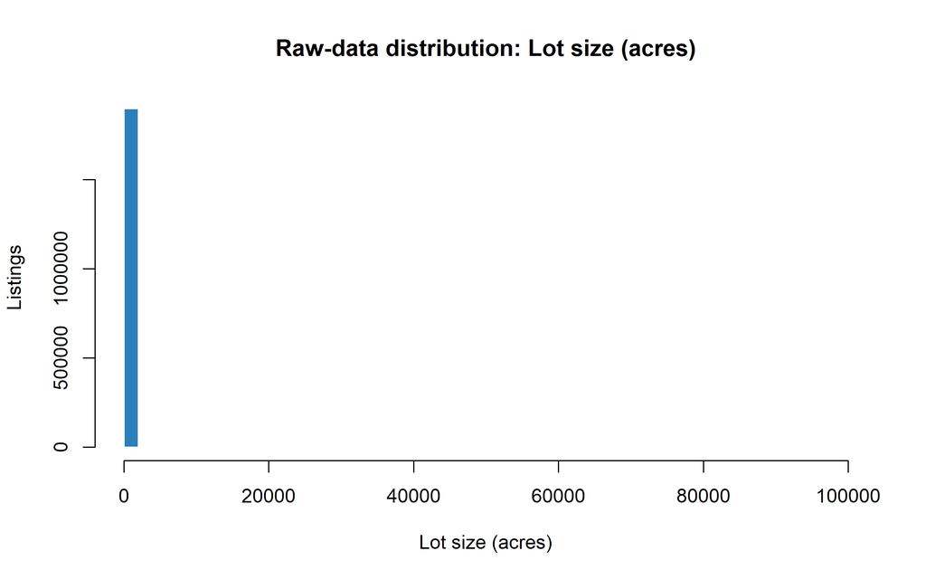

Lot size contains many small or zero values and a long right tail, motivating the log1p transformation.

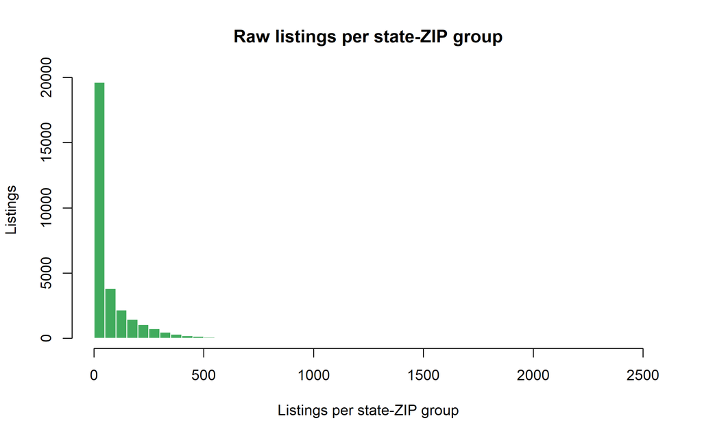

ZIP sample sizes are highly uneven in the raw data, motivating a balanced state-ZIP analysis sample.

The distribution plots show why modeling directly on the dollar scale would be fragile: both price and size have long right tails. The log transformations reduce extreme leverage while preserving order. The ZIP-count plot also shows that a purely raw-data analysis would be dominated by heavily represented ZIP codes; the balanced sample makes state-ZIP comparisons computationally feasible and more stable for MCMC diagnostics.

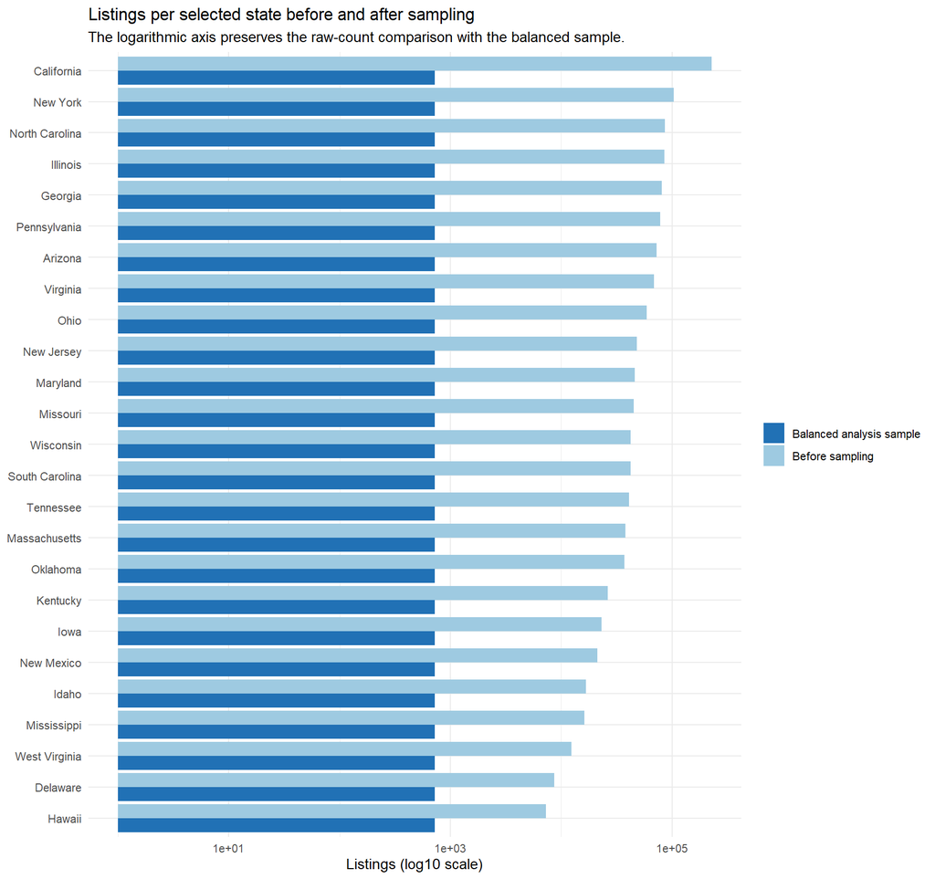

Selected states retain a transparent link to the raw data while using a balanced analysis sample.

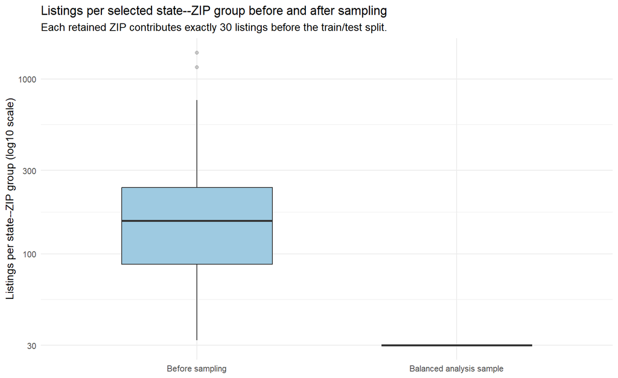

Selected state-ZIP groups contribute equal sample sizes before the train/test split.

# 4 Bayesian statistical models

## 4.1 Model sequence

The project compares three Bayesian models fit to the same training data:

- **M0: pooled regression.** A common intercept, fixed covariate effects, and a single residual scale.
- **M1: state hierarchy.** M0 plus state-level random intercepts.
- **M2: heteroskedastic state-ZIP hierarchy.** M1 plus ZIP random intercepts nested within states and a residual scale that varies by covariates and state.

For listing $i$, let $y_i$ be standardized log price, $\boldsymbol{x}_i$ be the covariate vector, $s[i]$ the state index, and $z[i]$ the ZIP index. The models are:

$$\begin{aligned}
\text{M0:}\quad y_i &\sim \text{Normal}(\mu_i,\sigma), &
\mu_i &= \alpha + \boldsymbol{x}_i^\top\boldsymbol{\beta},\\
\text{M1:}\quad y_i &\sim \text{Normal}(\mu_i,\sigma), &
\mu_i &= \alpha + \boldsymbol{x}_i^\top\boldsymbol{\beta} +
u_{s[i]},\\
\text{M2:}\quad y_i &\sim \text{Normal}(\mu_i,\sigma_i), &
\mu_i &= \alpha + \boldsymbol{x}_i^\top\boldsymbol{\beta} + u_{s[i]}
+ v_{z[i]},\\
&& \log(\sigma_i) &= \gamma_0 +
\boldsymbol{x}_i^\top\boldsymbol{\gamma} + h_{s[i]}.
\end{aligned}$$

In M2, $u_s$ are state deviations, $v_z$ are ZIP deviations centered within state, and $h_s$ are state-level residual-scale effects. The sum-to-zero centering makes the intercept identifiable as an overall mean and prevents geographic effects from competing unnecessarily with the intercept.

## 4.2 Priors and inferential targets

The intercept uses a weakly informative Normal prior centered at zero on the standardized log-price scale. Fixed effects use weak Normal priors, and scale parameters use proper half-Normal priors. The inferential targets are posterior distributions for:

- fixed covariate effects $\beta$;
- state and ZIP partial-pooling variation;
- residual-scale heterogeneity through $\gamma$, $\gamma_0$, and $h_s$;
- posterior predictive distributions for future listings.

Prior predictive simulation checks whether the model can generate plausible price ranges before seeing the outcome data.

```
##
##
## Table: Prior predictive simulation settings.
##
## | n_prior_draws|     seed| alpha_sd| beta_sd| sigma_sd| sd_state_sd| sd_zip_sd|revision_reason                                                                                            |
## |-------------:|--------:|--------:|-------:|--------:|-----------:|---------:|:----------------------------------------------------------------------------------------------------------|
## |           200| 20260621|        1|    0.03|      0.5|         0.3|       0.3|Original scales generated pathological prior-predictive price ranges with extreme standardized covariates. |
```

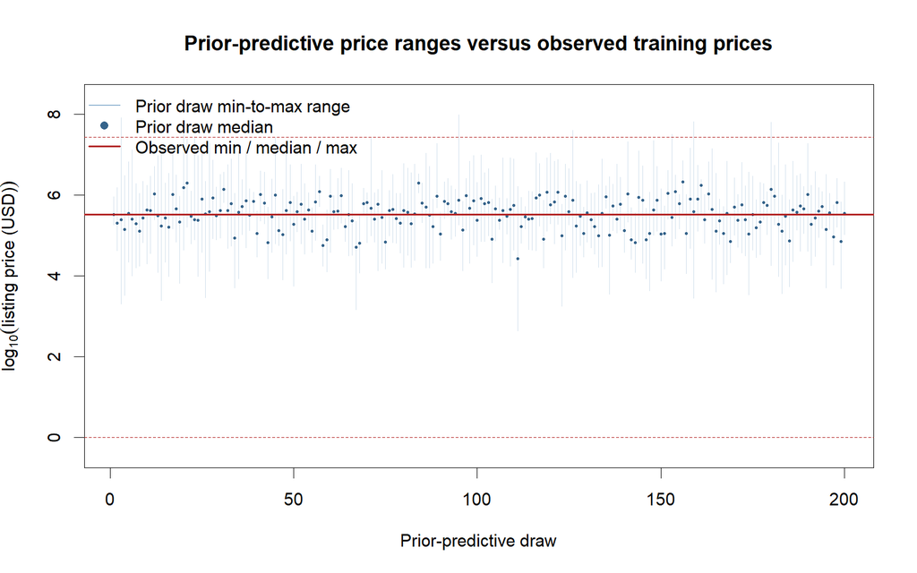

Prior predictive price ranges are compared with observed training prices on the dollar scale.

The prior predictive plot confirms that the calibrated priors generate broad but interpretable price ranges. This check is important because overly diffuse priors on standardized covariates can produce implausibly extreme dollar prices even before any data are used.

# 5 Simulation-based parameter recovery

The project includes a simulation recovery study in which outcomes are generated from known parameter values and then refit with the Bayesian workflow. This checks whether the computational model can recover parameters under controlled conditions.

```
##
##
## Table: Repeated simulation recovery completion summary.
##
## |quantity                       | value|
## |:------------------------------|-----:|
## |Repeated recovery replications |    20|
## |Completed                      |    20|
## |Converged                      |    20|
```

```
##
##
## Table: Simulation recovery parameter metrics.
##
## |Parameter                  | True value| Converged fits| Empirical 95% coverage| Posterior mean bias| Posterior mean RMSE|
## |:--------------------------|----------:|--------------:|----------------------:|-------------------:|-------------------:|
## |alpha                      |       0.00|             20|                   0.75|               0.018|               0.024|
## |beta[1] (log_house_size_z) |       0.45|             20|                   0.00|              -0.114|               0.115|
## |beta[2] (log_acre_lot_z)   |       0.08|             20|                   1.00|              -0.002|               0.010|
## |beta[3] (bed_z)            |       0.06|             20|                   0.15|               0.043|               0.044|
## |beta[4] (bath_z)           |       0.16|             20|                   1.00|               0.006|               0.012|
## |beta[5] (statussold)       |       0.05|             20|                   0.75|              -0.034|               0.038|
## |sd_state                   |       0.30|             20|                   0.85|               0.029|               0.082|
## |sd_zip                     |       0.25|             20|                   0.90|               0.007|               0.026|
## |sigma                      |       0.55|             20|                   0.90|               0.007|               0.010|
```

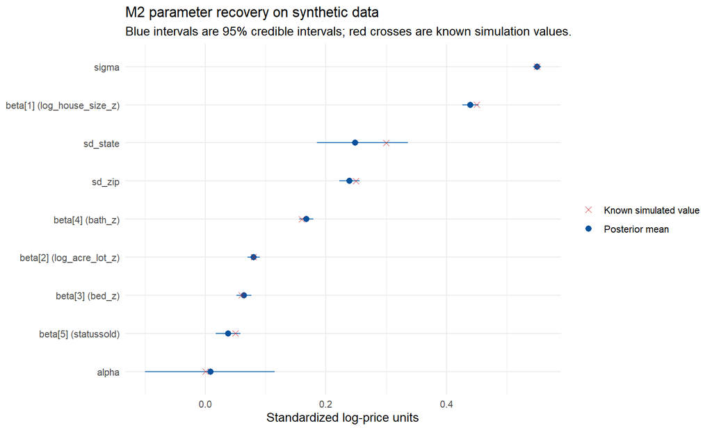

Scalar parameter recovery compares known simulated values with posterior means and 95% credible intervals.

The larger reduced-design recovery run completed and converged for all 20 replications. Recovery is strongest for several scale and covariate parameters, while coverage is weaker for some fixed effects. This is not a script failure; it indicates that the reduced simulation design is a stress test and that finite-sample bias or covariate structure can affect interval calibration. The recovery results are therefore interpreted as computational validation with a documented diagnostic caveat rather than as proof that all real-data posterior intervals are perfectly calibrated.

# 6 MCMC computation and diagnostics

The posterior was approximated using four MCMC chains. For the selected heteroskedastic M2 fit, each chain used 2,000 adaptation iterations, 5,000 warm-up iterations, and 10,000 retained sampling iterations, giving 40,000 posterior draws. DIC was computed with a separate lightweight live-JAGS refit because `dic.samples()` requires live model objects rather than saved posterior draws (Spiegelhalter et al. 2002).

```
##
##
## Table: M2 MCMC and posterior-check settings.
##
## |   |setting                 |value    |
## |:--|:-----------------------|:--------|
## |1  |n_chains                |4        |
## |2  |n_adapt                 |2000     |
## |3  |n_burn                  |5000     |
## |4  |n_iter                  |10000    |
## |5  |thin                    |1        |
## |6  |seed                    |20260703 |
## |7  |chunk_iter              |1000     |
## |8  |max_heldout_draws       |2000     |
## |9  |max_ppc_draws           |1000     |
## |11 |sigma_prior_center      |0.5      |
## |12 |gamma0_prior_scale      |0.5      |
## |13 |gamma_prior_scale       |0.2      |
## |14 |sigma_state_prior_scale |0.2      |
```

```
##
##
## Table: Numerical convergence and Monte Carlo accuracy summary for M2.
##
## |quantity                    |value    |
## |:---------------------------|:--------|
## |Monitored parameters        |665      |
## |Converged parameters        |665      |
## |Maximum R-hat               |1.0007   |
## |Minimum bulk ESS            |6,756.3  |
## |Minimum tail ESS            |12,558.3 |
## |Maximum MCSE / posterior SD |0.0122   |
```

All 665 monitored M2 parameters passed the pre-specified convergence checks. The maximum R-hat was 1.0007, the minimum bulk ESS was 6,756.3, and the maximum MCSE/posterior-SD ratio was 0.0122. These diagnostics support using the posterior draws for inference and prediction.

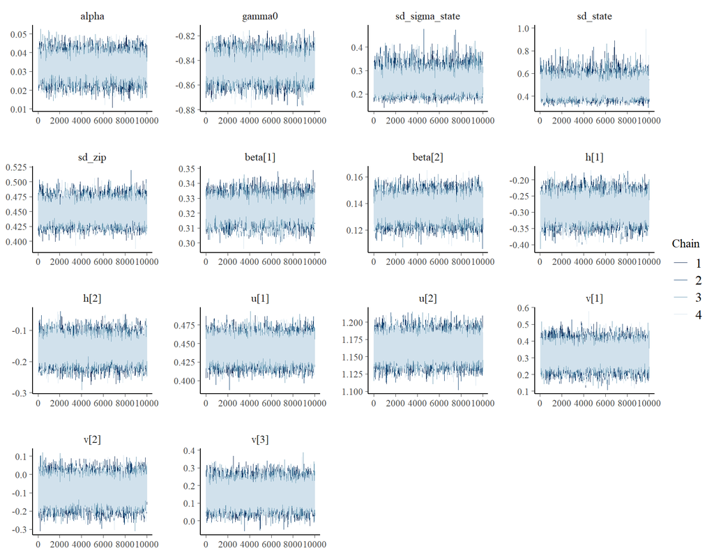

Trace plots should show stable mixing without persistent chain separation.

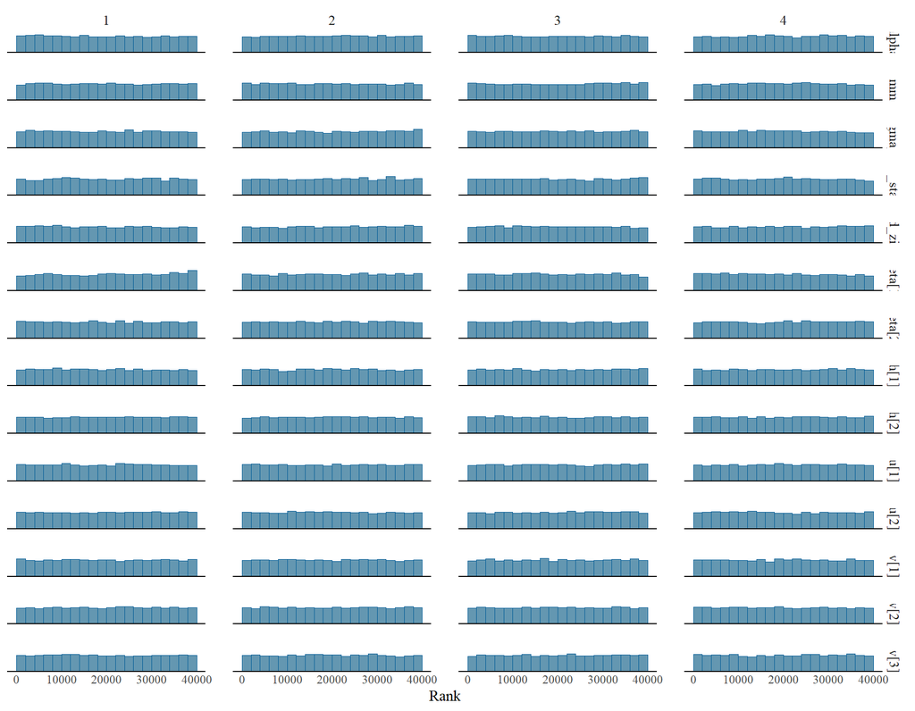

Rank histograms check whether chains explore the same posterior distribution.

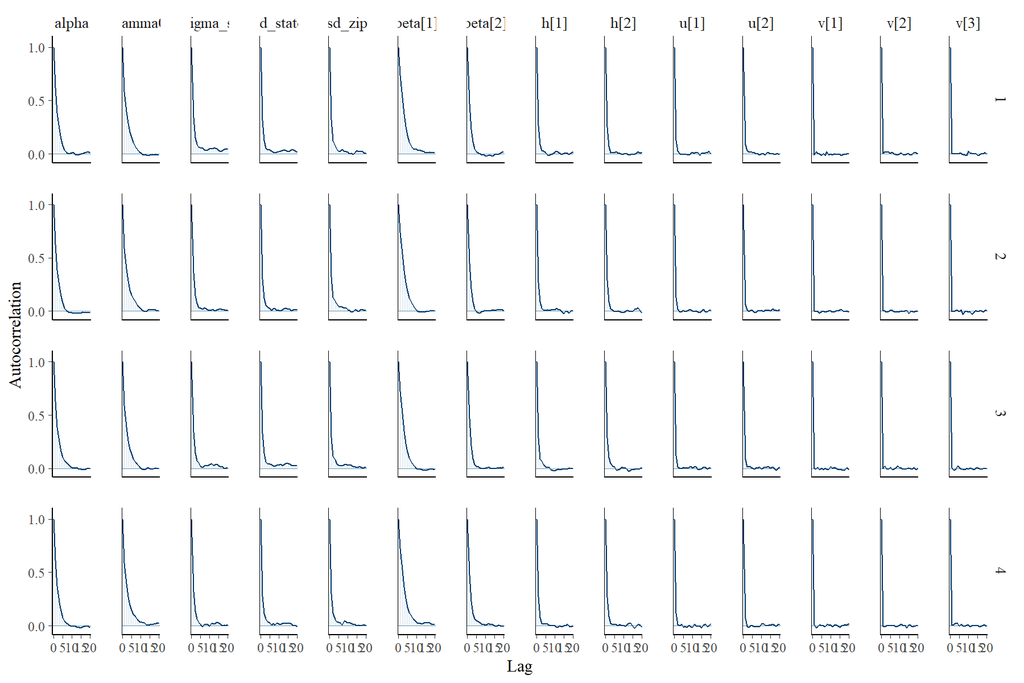

Autocorrelation plots assess dependence between successive MCMC draws.

The diagnostic plots are read together with the numerical summary. Stable traces, overlapping rank behavior, and acceptable autocorrelation support the conclusion that the MCMC approximation is adequate for the displayed posterior summaries.

# 7 Posterior inference

## 7.1 Fixed effects and variance components

```
##
##
## Table: M2 fixed-effect posterior summaries.
##
## |Effect           | Posterior median| Lower 95%| Upper 95%| Pr(effect > 0)|
## |:----------------|----------------:|---------:|---------:|--------------:|
## |log_house_size_z |            0.323|     0.310|     0.335|          1.000|
## |log_acre_lot_z   |            0.137|     0.123|     0.150|          1.000|
## |bed_z            |           -0.015|    -0.025|    -0.004|          0.004|
## |bath_z           |            0.209|     0.194|     0.224|          1.000|
## |statussold       |           -0.071|    -0.085|    -0.057|          0.000|
```

```
##
##
## Table: M2 residual and geographic variation summaries.
##
## |   |Quantity                | Posterior median| Lower 95%| Upper 95%| Posterior probability|
## |:--|:-----------------------|----------------:|---------:|---------:|---------------------:|
## |6  |Typical residual SD     |            0.388|     0.381|     0.394|                    NA|
## |7  |Residual-scale state SD |            0.245|     0.189|     0.331|                    NA|
## |8  |State SD                |            0.469|     0.366|     0.620|                    NA|
## |9  |ZIP SD                  |            0.449|     0.424|     0.477|                    NA|
## |10 |ZIP SD - State SD       |           -0.019|    -0.173|     0.087|                 0.376|
## |11 |P(ZIP SD > State SD)    |               NA|        NA|        NA|                 0.376|
```

The fixed effects have the expected qualitative pattern. Larger living area and larger lot size are associated with higher listing prices, and bathrooms have a clear positive association. Bedrooms have a small negative association after controlling for living area and bathrooms, which is plausible because additional bedrooms at fixed size can reflect smaller rooms or different property configurations. The sold-status coefficient is negative relative to the reference status in this balanced modeling frame.

The posterior median typical residual SD is 0.388. State and ZIP variation are both substantial, indicating that geographic partial pooling remains important after property features are included.

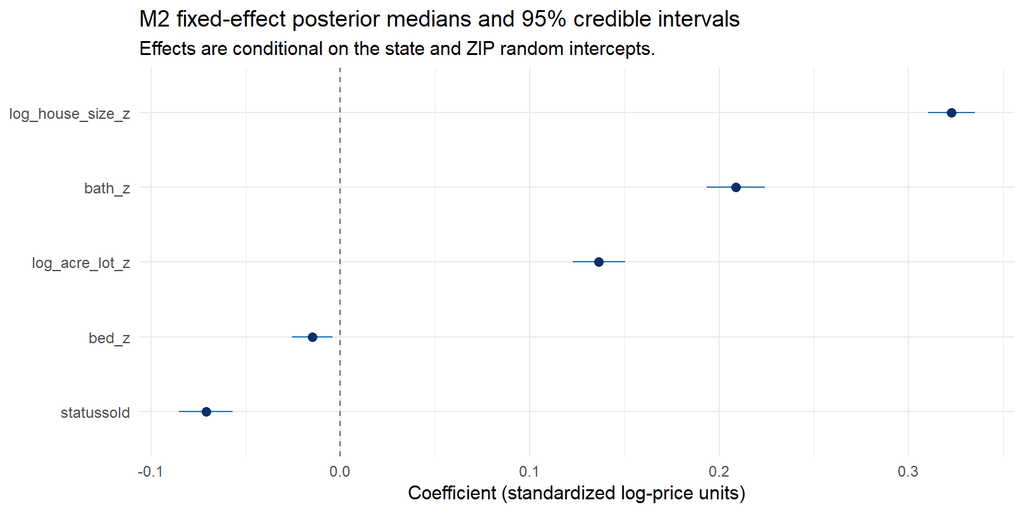

Fixed-effect forest plot: intervals away from zero indicate strong posterior evidence for an association.

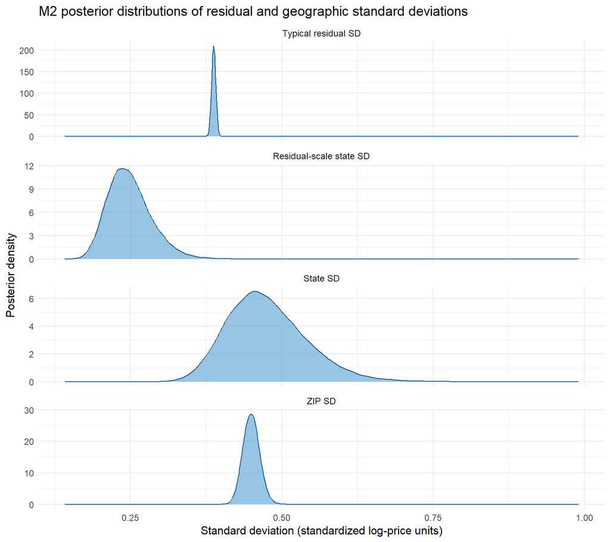

Variance-component posteriors: residual, state, and ZIP scales quantify remaining unexplained variation.

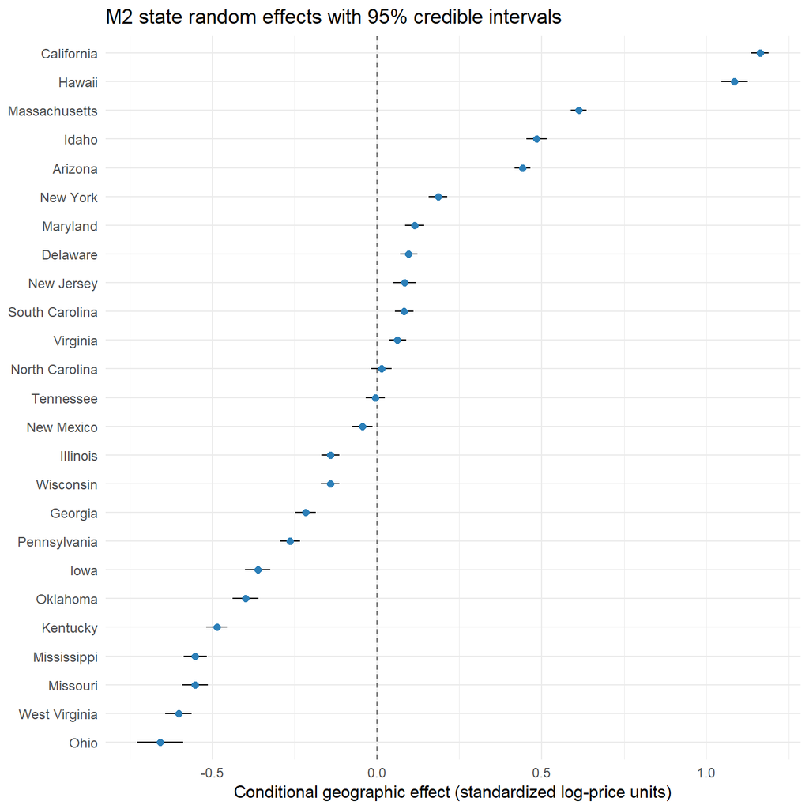

State-effect caterpillar plot: state effects are partial-pooling deviations from the overall intercept.

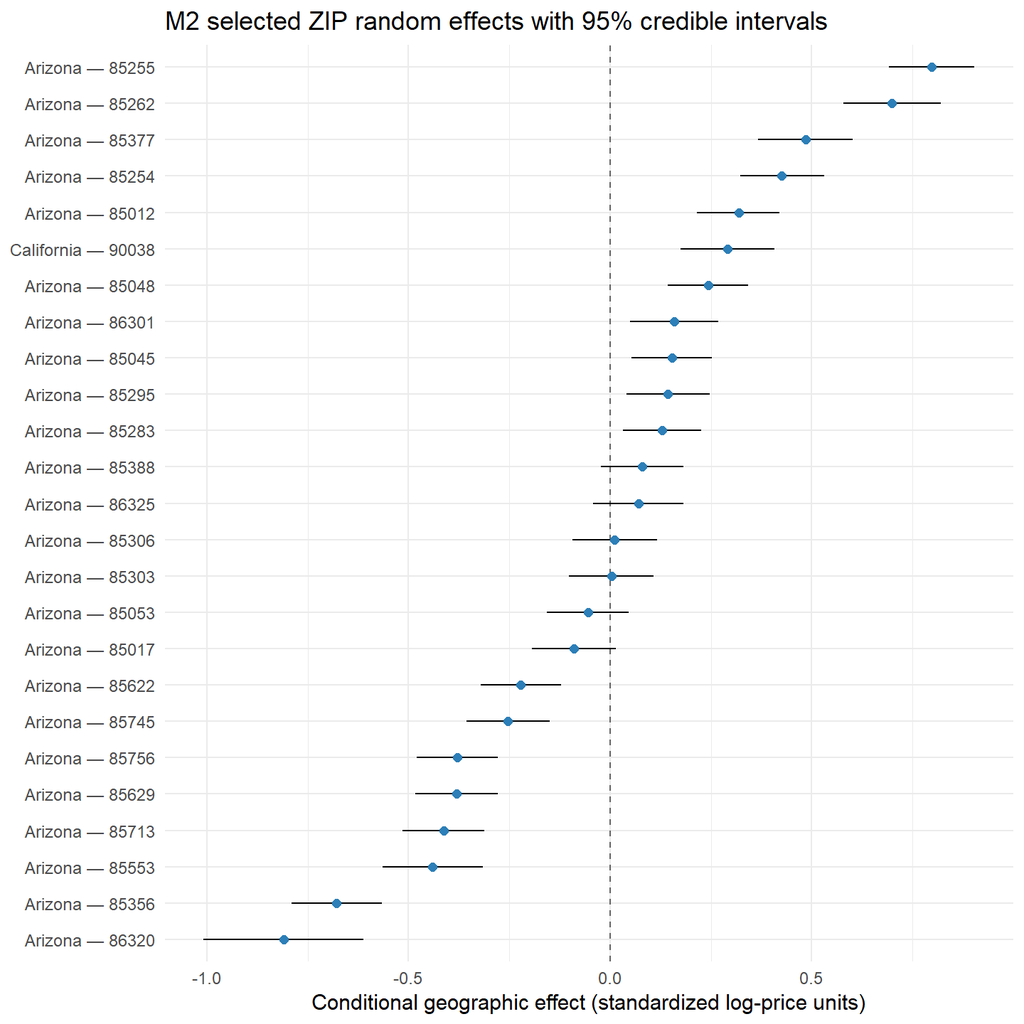

Selected ZIP-effect caterpillar plot: ZIP effects are local deviations centered within states.

The caterpillar plots should not be interpreted causally. They show residual geographic associations conditional on the included covariates. The hierarchical structure shrinks uncertain state and ZIP effects toward their group-level distributions, reducing instability relative to separate unpooled estimates.

## 7.2 Posterior predictive scenarios

```
##
##
## Table: Posterior predictive dollar-price scenarios.
##
## |Scenario                                                  |State      |   ZIP| Median price|  50% lower| 50% upper|  95% lower| 95% upper|
## |:---------------------------------------------------------|:----------|-----:|------------:|----------:|---------:|----------:|---------:|
## |Representative home: low adjusted-price observed ZIP      |Missouri   | 63115|     49165.24|   36362.52|   65670.5|   20903.81|    114858|
## |Representative home: high adjusted-price observed ZIP     |California | 90291|   2072324.55| 1699877.61| 2513048.1| 1181219.56|   3741296|
## |Representative home: new ZIP in high adjusted-price state |California |    NA|    844856.03|  610501.41| 1180848.3|  329422.38|   2260487|
```

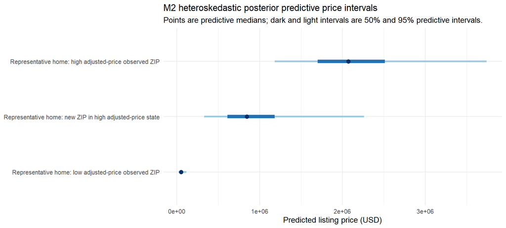

Posterior predictive price intervals include both parameter uncertainty and listing-level residual variation.

The scenario predictions illustrate the size of geographic effects. A representative home in a high adjusted-price observed ZIP has a much higher posterior predictive median than the same property profile in a low adjusted-price observed ZIP. A new ZIP in the high-price state has a lower and wider distribution than the observed high-price ZIP because its ZIP effect is not observed and must be drawn from the ZIP-level distribution.

# 8 Model comparison

## 8.1 DIC and held-out predictive performance

```
##
##
## Table: DIC and held-out predictive comparison.
##
## |Model                           |      DIC| Delta DIC|  RMSE|   MAE| 95% coverage|   MLPD|
## |:-------------------------------|--------:|---------:|-----:|-----:|------------:|------:|
## |M2: heteroskedastic state + ZIP | 15333.34|      0.00| 0.424| 0.283|        0.954| -0.490|
## |M1: state                       | 29452.74|  14119.40| 0.597| 0.429|        0.957| -0.915|
## |M0: pooled                      | 35023.39|  19690.05| 0.762| 0.557|        0.952| -1.151|
```

M2 is clearly preferred. Its DIC is 15,333.34, compared with 29,452.74 for M1 and 35,023.39 for M0. On the held-out test set, M2 also has the lowest RMSE and MAE and the best mean log predictive density. Its 95% predictive coverage is 0.9536, close to the nominal 0.95 target. The agreement between DIC and held-out predictive performance supports the selected hierarchical structure.

# 9 Posterior predictive model checking

Posterior predictive checks evaluate whether replicated data generated from the fitted model reproduce important features of the observed training data. The chosen checks target central tendency, distributional spread, upper-tail behavior, state medians, and ZIP-level geographic variation.

```
##
##
## Table: Key M2 posterior predictive checks.
##
## |   |Statistic               | Observed| Replicated median| Replicated lower 95%| Replicated upper 95%| Tail probability|
## |:--|:-----------------------|--------:|-----------------:|--------------------:|--------------------:|----------------:|
## |18 |Overall IQR             |    1.109|             1.215|                1.198|                1.236|            1.000|
## |19 |Overall 90th percentile |    1.127|             1.218|                1.196|                1.245|            1.000|
## |20 |ZIP mean variance       |    0.564|             0.576|                0.559|                0.593|            0.905|
```

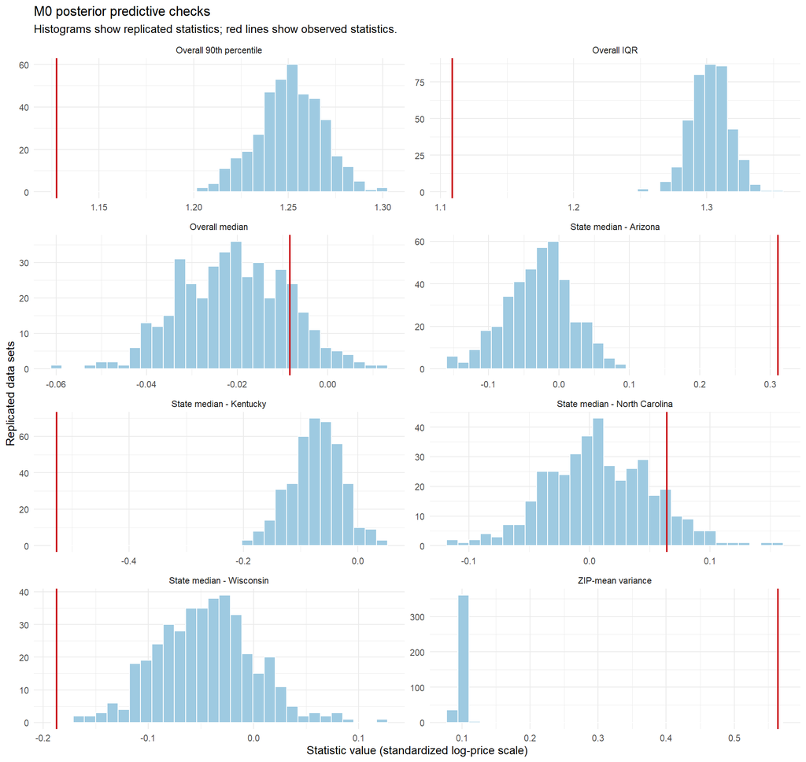

M0 posterior predictive checks: the pooled model misses substantial geographic heterogeneity.

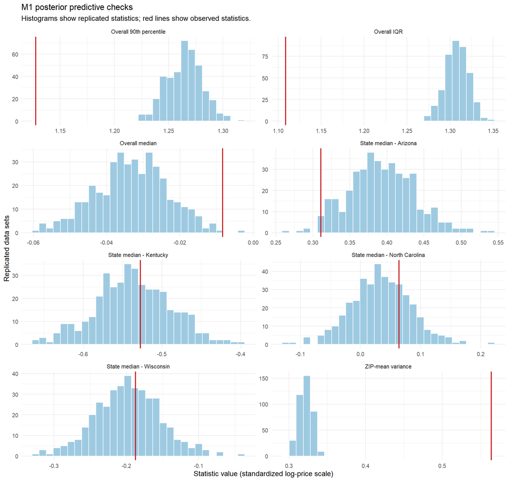

M1 posterior predictive checks: state effects improve geography but still understate ZIP-level variation.

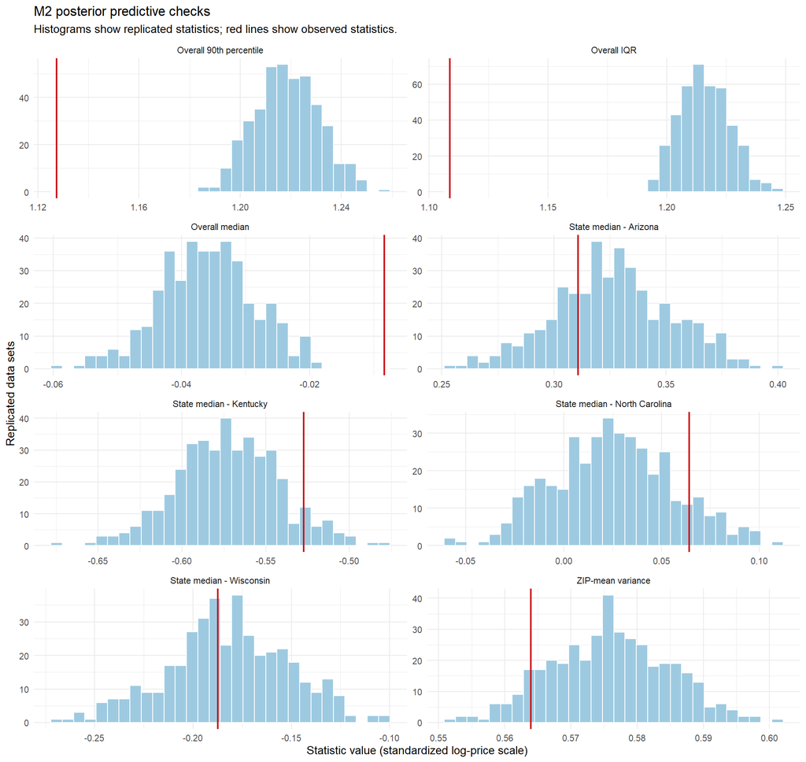

M2 posterior predictive checks: geographic variation is well reproduced, while overall IQR and upper-tail spread remain mildly high.

M2 reproduces the ZIP mean variance closely: the observed value is 0.564 and the replicated median is 0.5759. The overall IQR and 90th percentile remain moderately above the observed values in replicated data. This means the selected model captures the main geographic structure but still slightly over-disperses the marginal standardized log-price distribution. The discrepancy is reported as a model-checking caveat and a direction for future refinement, not as invalidation of the model.

# 10 Discussion

The results support a hierarchical Bayesian model for these real-estate listings. Moving from M0 to M1 improves geographic structure, but the state-only model cannot represent local ZIP-level variation. The heteroskedastic M2 improves both model comparison and held-out prediction while preserving calibrated predictive intervals.

Substantively, living area, lot size, and bathrooms are positively associated with listing price on the standardized log scale. Geographic effects remain important after these property features are included. The posterior predictive scenarios show that location-specific effects can strongly affect predicted dollar prices for otherwise similar representative homes.

The project also illustrates the value of formal Bayesian workflow checks. Prior predictive simulation prevented implausible prior scales, simulation recovery tested computational behavior under known data-generating values, MCMC diagnostics verified numerical reliability, DIC and held-out metrics compared models, and posterior predictive checks identified what the final model reproduces well and where it remains imperfect.

# 11 Conclusion

The heteroskedastic state-ZIP Bayesian hierarchical model provides the strongest and most interpretable analysis among the fitted models. It is preferred by DIC, held-out RMSE, held-out MAE, and mean log predictive density; it has calibrated 95% predictive coverage; and it reproduces geographic heterogeneity well. The remaining over-dispersion in overall IQR and upper-tail checks is a useful diagnostic for future work, especially for richer nonlinear mean structures or more detailed property-quality information.

# 12 Appendix

## 12.1 Reproducibility record

The project seed is `20260621`. The raw CSV is excluded from version control, while model code, report source, generated tables, and generated figures are versioned. Rendering this report reads saved analysis artifacts from `output/tables` and `output/figures`.

## 12.2 JAGS model code

### 12.2.1 M0: pooled regression

```
model {
  for (i in 1:N) {
    y[i] ~ dnorm(mu[i], tau_y)
    mu[i] <- alpha + inprod(beta[], X[i,])
  }

  # Prior-predictive calibration: alpha SD = 1 and beta SD = 0.03.
  alpha ~ dnorm(0, 1)
  for (p in 1:P) {
    beta[p] ~ dnorm(0, 1111.111111)
  }

  # Half-normal residual SD prior with scale 0.5.
  sigma ~ dnorm(0, 4) T(0,)
  tau_y <- pow(sigma, -2)
}
```

### 12.2.2 M1: state random intercepts

```
model {
  for (i in 1:N) {
    y[i] ~ dnorm(mu[i], tau_y)
    mu[i] <- alpha + inprod(beta[], X[i,]) + u[state[i]]
  }

  # Prior-predictive calibration: alpha SD = 1 and beta SD = 0.03.
  alpha ~ dnorm(0, 1)
  for (p in 1:P) {
    beta[p] ~ dnorm(0, 1111.111111)
  }

  for (s in 1:S) {
    u_raw[s] ~ dnorm(0, tau_state)
    u[s] <- u_raw[s] - u_mean
  }
  u_mean <- sum(u_raw[]) / S
  # Half-normal state-effect SD prior with scale 0.3.
  sd_state ~ dnorm(0, 11.111111) T(0,)
  tau_state <- pow(sd_state, -2)

  # Half-normal residual SD prior with scale 0.5.
  sigma ~ dnorm(0, 4) T(0,)
  tau_y <- pow(sigma, -2)
}
```

### 12.2.3 M2: heteroskedastic state-ZIP hierarchy

```
model {
  for (i in 1:N) {
    y[i] ~ dnorm(mu[i], tau_y[i])
    mu[i] <- alpha + inprod(beta[], X[i,]) + u[state[i]] + v[zip[i]]
    log_sigma[i] <- gamma0 + inprod(gamma[], X_sigma[i,]) + h[state[i]]
    sigma[i] <- exp(log_sigma[i])
    tau_y[i] <- pow(sigma[i], -2)
  }

  alpha ~ dnorm(0, 1)
  for (p in 1:P) {
    beta[p] ~ dnorm(0, 1111.111111)
  }

  for (q in 1:P_sigma) {
    gamma[q] ~ dnorm(0, tau_gamma_prior)
  }
  gamma0 ~ dnorm(log_sigma_prior_mean, tau_gamma0_prior)

  for (s in 1:S) {
    h_raw[s] ~ dnorm(0, tau_sigma_state)
    h[s] <- h_raw[s] - h_mean
  }
  h_mean <- sum(h_raw[]) / S
  sd_sigma_state ~ dnorm(0, tau_sigma_state_prior) T(0,)
  tau_sigma_state <- pow(sd_sigma_state, -2)

  for (s in 1:S) {
    u_raw[s] ~ dnorm(0, tau_state)
    u[s] <- u_raw[s] - u_mean
  }
  u_mean <- sum(u_raw[]) / S
  sd_state ~ dnorm(0, 11.111111) T(0,)
  tau_state <- pow(sd_state, -2)

  for (z in 1:Z) {
    v_raw[z] ~ dnorm(0, tau_zip)
    v[z] <- v_raw[z] - v_state_mean[zip_state[z]]
  }
  for (s in 1:S) {
    for (k in 1:K) {
      v_state_member[s,k] <- v_raw[zip_in_state[s,k]] * zip_in_state_weight[s,k]
    }
    v_state_sum[s] <- sum(v_state_member[s,])
    v_state_mean[s] <- v_state_sum[s] / n_zips_by_state[s]
  }
  sd_zip ~ dnorm(0, 11.111111) T(0,)
  tau_zip <- pow(sd_zip, -2)
}
```

Ahmed Shahriar Sakib. 2026. *USA Real Estate Dataset*. Kaggle dataset, version 25. https://www.kaggle.com/datasets/ahmedshahriarsakib/usa-real-estate-dataset.

Spiegelhalter, David J., Nicola G. Best, Bradley P. Carlin, and Angelika van der Linde. 2002. “Bayesian Measures of Model Complexity and Fit.” *Journal of the Royal Statistical Society: Series B* 64 (4): 583–639. https://doi.org/10.1111/1467-9868.00353.